# Biological age prediction

Charles Anchang

Last compiled on 18 Mai, 2024

## Introduction

The goal of this project is to predict the biological age of the normal and healthy colon samples in the DNA methylation dataset from the [genomicClass](https://github.com/genomicsclass/coloncancermeth/blob/master/data/coloncancermeth.rda) github page. The CpGs that determine the biological clock will be determined de novo using PCA and used as the predictors. A CpG is a C, followed by a G but from the $5^1$ end to the $3^1$ end of a DNA strand.

Epigenetic mechanisms regulate gene expression. Certain technologies enable us measure some epigenetic endpoints. One example is DNA methylation. DNA methylation is a chemical process that occurs around genes and which is capable of silencing gene expression. In this project, I will analyse DNA methylation data for the whole genome and relate it to phenotypic variation.

It has been studied that when part of a genome is methylated, the gene close to it is not expressed. It is inherited at mitosis. Methylation often occurs at CpG islands.

When one DNA strand is methylated, so is the other. If we also have a CpG on one strand, we have it as well on the other strand.When DNA replicates, its methylation characteristics are preserved.

## Mile stones

### Loading the data

```r
# load the data
coloncancermeth <- load("coloncancermeth.rda")
coloncancermeth
```

```
## [1] "meth" "gr"   "pd"
```

```r
dim(meth)
```

```
## [1] 485512     26
```

**Overview of the metadata**

```r
colnames(pd)
```

```
##   [1] "bcr_patient_barcode"
##   [2] "bcr_sample_uuid"
##   [3] "bcr_sample_barcode"
##   [4] "NCNNCT_OthMethONSP"
##   [5] "current_weight"
##   [6] "days_to_collection"
##   [7] "days_to_sample_procurement"
##   [8] "freezing_method"
##   [9] "initial_weight"
##  [10] "intermediate_dimension"
##  [11] "longest_dimension"
##  [12] "lymphatic_invasion"
##  [13] "margins_involved"
##  [14] "method_of_sample_procurement"
##  [15] "number_regional_lymphnodes_exam"
```

[output cut: 90 more lines]

### Perform PCA

The goal of performing PCA is to identify the CPGs that are strongly predictive of the age. The approach consists of identifying the principal components whose loading scores have a significant relationship with the outcome of interest which is the age. The top 24 CPGs with the highest loading scores in the PC with significant relationship with the age will be selected to serve as predictors in a linear model with age as outcome. The model will be used predict the age. This prediction will constitute the biological age.

```r
pca <- prcomp(t(meth), scale = TRUE)

## make a scree plot
pca.var <- pca$sdev^2
pca.var.per <- round(pca.var/sum(pca.var)*100, 1)
pca.var.per
```

```
##  [1] 16.6  9.4  7.7  6.0  5.4  4.9  4.6  4.0  3.9  3.8  3.6  3.3  3.1  3.0  2.9
## [16]  2.8  2.6  2.3  2.2  1.6  1.5  1.4  1.2  1.1  1.0  0.0
```

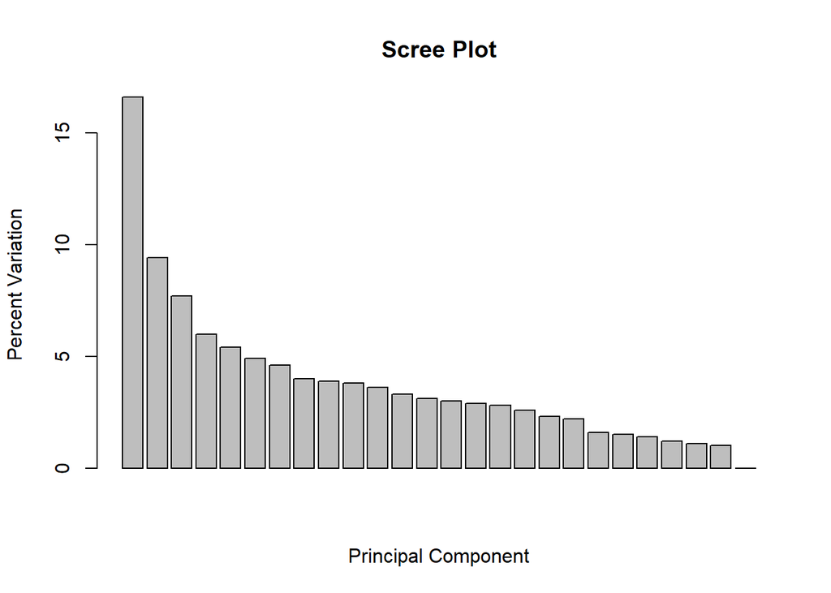

```r
barplot(pca.var.per,
        main="Scree Plot",
        xlab="Principal Component",
        ylab="Percent Variation")
```

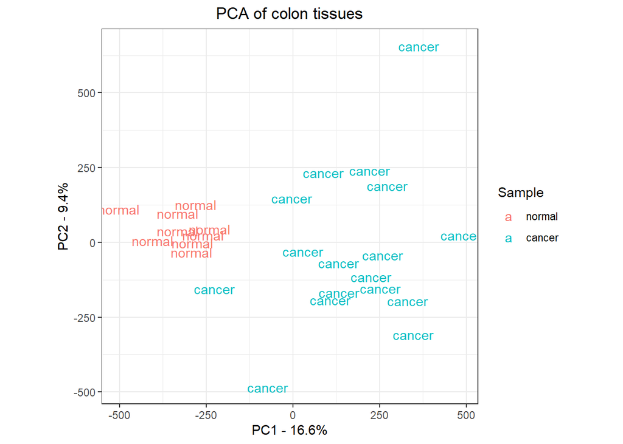

```r
pca.data <- data.frame(Sample=pd$Status,
  X=pca$x[,1],
  Y=pca$x[,2])

ggplot(data=pca.data, aes(x=X, y=Y,
                          label=Sample, color=Sample)) +
  geom_text() +
  xlab(paste("PC1 - ", pca.var.per[1], "%", sep="")) +
  ylab(paste("PC2 - ", pca.var.per[2], "%", sep="")) +
  theme_bw() +
  ggtitle("PCA of colon tissues")+
   theme(plot.title = element_text(hjust = 0.5),
         aspect.ratio = 1)
```

### Identify which principal components have a significant correlation with the age

**Assess the significance of the correlations of PCs with age**

```r
pcs <- as.data.frame(pca$x)

age <- pd$patient.age_at_initial_pathologic_diagnosis

p_values <- sapply(pcs, function(x){
     cort_test_p <- cor.test(x, age)$p.value
     cort_test_p
})
p_values[p_values <= 0.1]
```

```
##        PC2       PC10       PC20       PC26
## 0.01147288 0.07696937 0.06187828 0.08044917
```

**Get the top 24 CpGs that have the highest loading scores for PC2**

```r
## get the name of the top 24 measurements (cpgs) that contribute most to pc1.
loading_scores <- pca$rotation[,2]
cpgs_scores <- abs(loading_scores) ## get the magnitudes
cpgs_score_ranked <- sort(cpgs_scores, decreasing=TRUE)
top_cpgs_pc2<- names(cpgs_score_ranked[1:24])
```

Now that I have cpgs that have top loading scores or influence on the PCs that have significant correlation with the age at time of diagnosis, I can proceed to make a simple linear regression where I predict this chronological age, using the epigenetic signatures that correlate with the age.

```r
age_related_cpgs <- top_cpgs_pc2
length(age_related_cpgs)
```

```
## [1] 24
```

```r
t_meth <- as.data.frame(t(meth))
dim(t_meth)
```

```
## [1]     26 485512
```

```r
t_meth$age <- pd$patient.age_at_initial_pathologic_diagnosis
```

### Linear modelling

```r
lmod <- lm(age~.,data = t_meth[, c(age_related_cpgs,"age")])
summary(lmod)
```

```
##
## Call:
## lm(formula = age ~ ., data = t_meth[, c(age_related_cpgs, "age")])
##
## Residuals:
##        1        2        3        4        5        6        7        8
##  0.08007 -1.34122 -0.69445 -0.92844  0.31741 -0.93677  0.71484  0.93057
##        9       10       11       12       13       14       15       16
## -0.25950 -0.19924 -0.64197  0.92996 -0.19724 -0.46371 -0.08185 -0.52345
##       17       18       19       20       21       22       23       24
##  0.54431  0.90408 -0.17890  0.22033 -0.20480  1.37827  0.22678  1.50833
##       25       26
## -0.39167 -0.71174
##
## Coefficients:
##              Estimate Std. Error t value Pr(>|t|)
## (Intercept)   498.231    188.087   2.649   0.2298
## cg06487194    103.589     41.441   2.500   0.2423
## cg24123518    118.846     60.384   1.968   0.2993
## cg13273540     33.887     75.364   0.450   0.7310
## cg00099766   -161.122     37.552  -4.291   0.1458
## cg25966599     65.376    182.832   0.358   0.7814
## cg07559438     74.517    144.704   0.515   0.6973
## cg00609227    -73.096    103.241  -0.708   0.6078
## cg04383462    110.503     92.348   1.197   0.4432
## cg13085530    -82.946     32.777  -2.531   0.2396
## cg22242539    436.091     54.765   7.963   0.0795 .
## cg05976228    -96.803    213.686  -0.453   0.7292
## cg05322500     -5.397     86.391  -0.062   0.9603
## cg22597438  -1110.844    331.427  -3.352   0.1846
## cg03151165    -30.066     42.773  -0.703   0.6100
## cg00532411    -80.599     76.511  -1.053   0.4834
## cg07297832    -54.198     42.705  -1.269   0.4248
## cg00122406    -40.974     72.134  -0.568   0.6711
## cg14156446    391.883     68.918   5.686   0.1108
## cg26176014     67.709     93.116   0.727   0.5997
## cg10184845    230.815    157.965   1.461   0.3821
## cg18815879   -166.896    131.553  -1.269   0.4250
## cg17839324     65.269     45.135   1.446   0.3852
## cg09069593     -2.094     34.970  -0.060   0.9619
## cg20473374   -128.030     47.924  -2.672   0.2280
## ---
## Signif. codes:  0 '***' 0.001 '**' 0.01 '*' 0.05 '.' 0.1 ' ' 1
##
## Residual standard error: 3.68 on 1 degrees of freedom
## Multiple R-squared:  0.9975, Adjusted R-squared:  0.9381
## F-statistic:  16.8 on 24 and 1 DF,  p-value: 0.1907
```

**Model diagnostics**

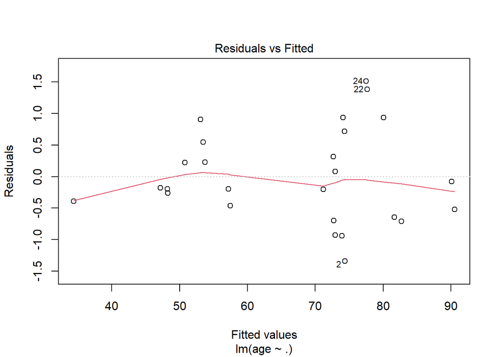

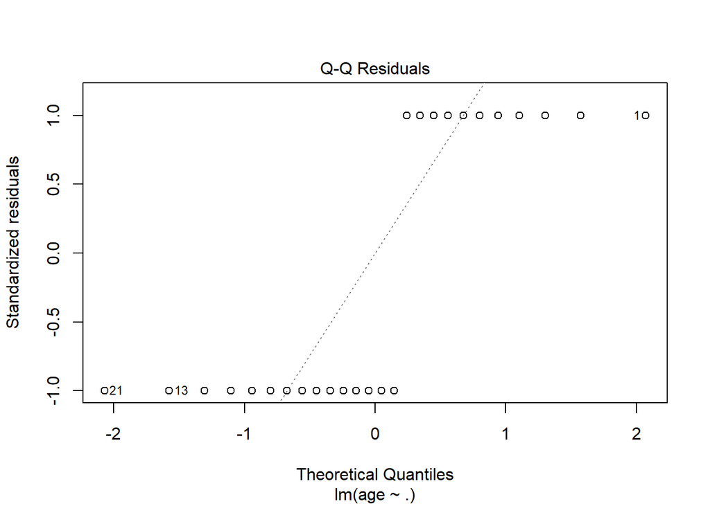

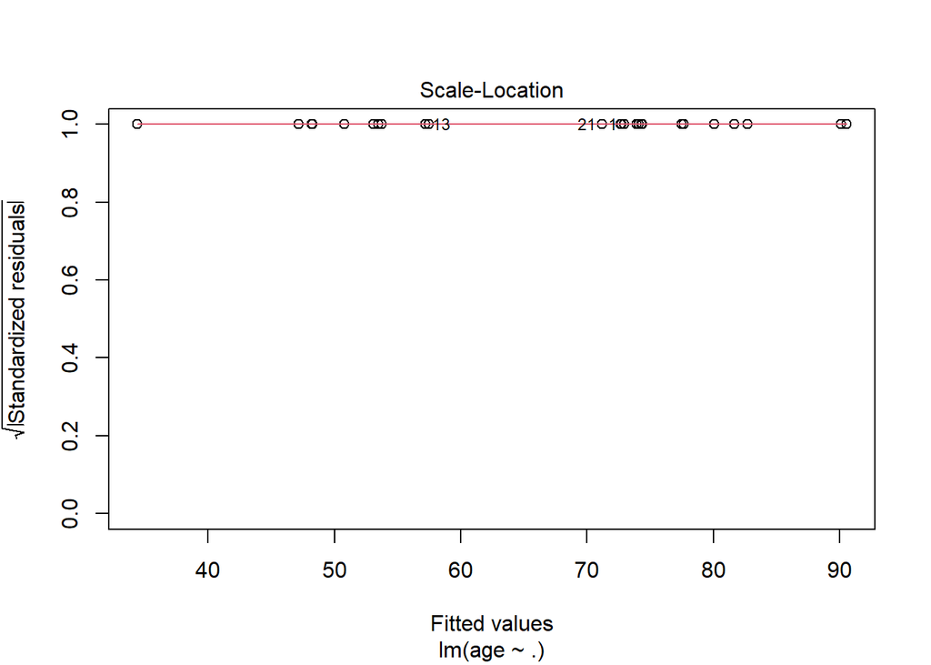

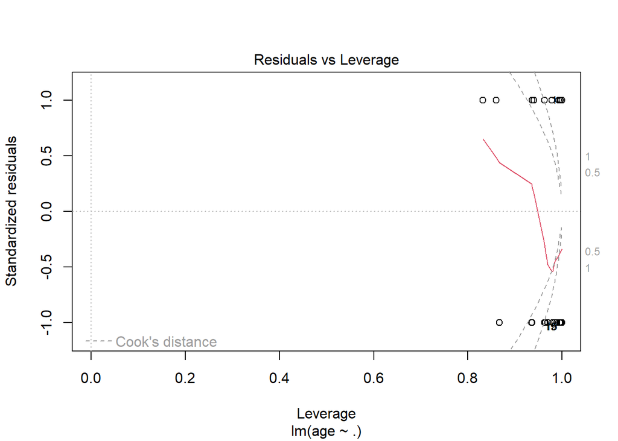

```r
plot(lmod)
```

```r
shapiro.test(resid(lmod))
```

```
##
##  Shapiro-Wilk normality test
##
## data:  resid(lmod)
## W = 0.96819, p-value = 0.577
```

The plot of the fitted points vs residuals does not show a pattern, showing that the model fits well and exhibits no heteroscedasticity. The Shapiro test on the residuals show that the p value is greater than 0.05, meaning that we do not have enough evidence to reject the null hypothesis of the normal distribution of residuals.

**Prediction of the biological age**

```r
t_meth$predicted_age <- predict(lmod, t_meth)
cor(t_meth$predicted_age, t_meth$age)
```

```
## [1] 0.9987622
```

The results above show a correlation coefficient of almost 1, as expected in literature.

```r
pd$Status
```

```
##  [1] cancer normal normal cancer normal cancer normal cancer normal cancer
## [11] cancer normal normal cancer cancer normal cancer normal cancer cancer
## [21] cancer cancer cancer cancer cancer cancer
## Levels: normal cancer
```

```r
res <- data.frame(Status = pd$Status,
                 Age = t_meth$age,
                 Predicted_age = t_meth$predicted_age)
res$Sq_error <-  (res$Age - res$Predicted_age)^2
res <- res[order(res$Sq_error, decreasing = T), ]
res %>%knitr:: kable("pipe")
```

|  | Status | Age | Predicted_age | Sq_error |
| --- | --- | --- | --- | --- |
| 24 | cancer | 79 | 77.49168 | 2.2750443 |
| 22 | cancer | 79 | 77.62173 | 1.8996392 |
| 2 | normal | 73 | 74.34122 | 1.7988678 |
| 6 | cancer | 73 | 73.93677 | 0.8775409 |
| 8 | cancer | 75 | 74.06943 | 0.8659543 |
| 12 | normal | 81 | 80.07004 | 0.8648337 |
| 4 | cancer | 72 | 72.92844 | 0.8619953 |
| 18 | normal | 54 | 53.09592 | 0.8173634 |
| 7 | normal | 75 | 74.28516 | 0.5110017 |
| 26 | cancer | 82 | 82.71174 | 0.5065807 |
| 3 | normal | 72 | 72.69445 | 0.4822665 |
| 11 | cancer | 81 | 81.64197 | 0.4121252 |
| 17 | cancer | 54 | 53.45569 | 0.2962715 |
| 16 | normal | 90 | 90.52345 | 0.2740050 |
| 14 | cancer | 57 | 57.46371 | 0.2150293 |
| 25 | cancer | 34 | 34.39167 | 0.1534081 |
| 5 | normal | 73 | 72.68259 | 0.1007501 |
| 9 | normal | 48 | 48.25950 | 0.0673424 |
| 23 | cancer | 54 | 53.77322 | 0.0514302 |
| 20 | cancer | 51 | 50.77967 | 0.0485472 |
| 21 | cancer | 71 | 71.20480 | 0.0419417 |
| 10 | cancer | 48 | 48.19924 | 0.0396956 |
| 13 | normal | 57 | 57.19724 | 0.0389034 |
| 19 | cancer | 47 | 47.17890 | 0.0320036 |
| 15 | cancer | 90 | 90.08185 | 0.0066996 |
| 1 | cancer | 73 | 72.91993 | 0.0064111 |

### Hypothesis testing To see if biological age differs significantly in the cancer vs normal groups.

```r
t_meth$Status <- pd$Status
table(t_meth$Status)
```

```
##
## normal cancer
##      9     17
```

```r
healthy_age <- t_meth[t_meth$Status == "normal", ]$predicted_age
cancer_age <- t_meth[t_meth$Status == "cancer", ]$predicted_age
t.test(healthy_age, cancer_age)
```

```
##
##  Welch Two Sample t-test
##
## data:  healthy_age and cancer_age
## t = 0.56832, df = 18.488, p-value = 0.5767
## alternative hypothesis: true difference in means is not equal to 0
## 95 percent confidence interval:
##  -9.051849 15.782422
## sample estimates:
## mean of x mean of y
##  69.23884  65.87355
```

The p value after the t test, not assuming equal variance in the two groups is greater than 0.5, which implies we do not have strong evidence to reject the null hypothesis. This implies that the biological age does not differ significantly in the normal vs cancer tissues.

### Conclusion

PCA can be used as feature selection to select CPG ptedictors of the biological age, when we have very few observations like in this case, 26. Otherwise, lasso regression and pther robust feature selectionmedthods can be used.